# Analysing factors affecting delays in Indian construction projects - ScienceDirect

- [View **PDF**](https://www.sciencedirect.com/science/article/pii/S0263786311001384/pdfft?md5=0c1b003bf139fdd588a26ef93ce67624&pid=1-s2.0-S0263786311001384-main.pdf)

## [International Journal of Project Management](https://www.sciencedirect.com/journal/international-journal-of-project-management)

[Volume 30, Issue 4](https://www.sciencedirect.com/journal/international-journal-of-project-management/vol/30/issue/4), May 2012, Pages 479-489

# Analysing factors affecting delays in Indian construction projects

, , ,

https://doi.org/10.1016/j.ijproman.2011.10.004[Get rights and content](https://s100.copyright.com/AppDispatchServlet?publisherName=ELS&contentID=S0263786311001384&orderBeanReset=true)

## Abstract

Construction projects in India are experiencing widespread delays. Due to a dramatic shift in the capacity and volume of the Indian construction sector over the last decade, the need of a [systematic analysis](https://www.sciencedirect.com/topics/engineering/systematic-analysis) of the reasons of delays and developing a clear understanding among the industry professionals are highly crucial. Using a selected set of 45 attributes, this research first identified the key factors impacting delay in Indian construction industry and then established the relationship between the critical attributes for developing prediction models for assessing the impacts of these factors on delay. A questionnaire and personal interviews have formed the basis of this research. Factor analysis and regression modelling were used to examine the significance of the delay factors. From the factor analysis, most critical factors of construction delay were identified as (1) lack of commitment; (2) inefficient site management; (3) poor site coordination; (4) improper planning; (5) lack of clarity in project scope; (6) lack of communication; and (7) substandard contract. Regression model indicates slow decision from owner, poor labour productivity, architects' reluctance for change and rework due to mistakes in construction are the reasons that affect the overall delay of the project significantly. These findings are expected to be significant contributions to Indian construction industry in controlling the time overruns in construction contracts.

- [Previous article in issue](https://www.sciencedirect.com/science/article/pii/S0263786311001256)
- [Next article in issue](https://www.sciencedirect.com/science/article/pii/S026378631100127X)

## Keywords

Time delay

Indian construction industry

Factor analysis

Regression modelling

## 1. Introduction

The Indian construction sector has acted as an engine of growth for the Indian economy for over the past five-decades and becoming a basic input for the socio-economic development of the country. Construction is the second largest economic activity after agriculture, and has contributed around 6 to 9% of India's GDP over the past five years while registering 8 to 10% growth per annum. The investments made in construction were reported to be close to USD 50 billion in 2008 with persistent growth pattern expected for much of the next decade. Contribution of the industry in terms of employment is also significant providing 31.46 million jobs; with about 1.25 million engineering jobs in 2008–2009. As per government data, the demand for construction manpower is projected to grow at a consistent pace of 8%–9%, thereby resulting in an annual addition of around 2.5 million jobs to the existing stock with approximately 125,000 new engineering jobs being added annually. Regardless of the economic importance and employment generation of the sector, issues such as low productivity, limited mechanisation and lack of professionally qualified employees plague the industry.

While the importance of Indian construction sector over the past five years has grown significantly, lack of sophistication across the construction supply chain is one of the key issues in the industry. There is strong evidence of inconsistent performance of Indian construction projects and the trend is growing rapidly. Projects are reportedly failing across all the key [performance measures](https://www.sciencedirect.com/topics/engineering/performance-measure-psi) including cost, time and quality performances. While understanding of the intrinsic factors affecting all these key performance measures is still an area of investigation at least in the Indian context, this research focuses on the analysis of performance in terms of timely delivery of construction projects. By earlier estimate, over 40% projects have reportedly been suffering from poor performance across the country (Iyer and Jha, 2005). In a separate study comparing the performance of international development projects in India, China, Bangladesh, and Thailand, Ahsan and Gunawan (2010) reported that construction projects in India showed the worst schedule performance (Ahsan and Gunawan, 2010). The study found that in India average schedule overrun is the highest (55% of actual schedule) compared to the other nations. Construction projects, especially infrastructure projects, in India have come under tremendous international scrutiny in the wake of the recent 2010 Commonwealth Games (Hindustan Times, August 2009). The current status report published by the Ministry of Statistics and Programme Implementation (MOSPI) highlighted that out of the 951 projects being monitored 309 projects have cost overruns and 474 projects are behind schedule. MOSPI has reported that “Of the total reported cost increase of USD 12.4 billion, USD 8.4 billion is on 466 delayed projects” ([www.mospi.nic.in](http://www.mospi.nic.in/)). Reasons for these problems range from land acquisition, improper planning and budgeting, to poor coordination and monitoring of the projects.

With this growing volume, schedule performance of the Indian construction sector is a certainly significant topic for investigation. While many studies have published on causes and factors affecting schedule and cost performance, most of the studies are area specific (Kim et al., 2008, Odeh and Battaine, 2002). Applicability of such research in Indian construction context still remains unexplored. There is a strong need to understand the attributes that cause the delays, understand the impact of these attributes, combine them into factors, and decipher the interdependencies between these factors. Thus, the primary objectives of this research are to identify the various attributes for construction delay, to identify the relationship between these attributes by statistical methods and to predict the impact of these identified attributes on construction delay using a regression model in the Indian construction sector.

## 2. Literature review

Delay in construction projects has been a research topic for decades. Research conducted in this area is broadly divided into two streams—one stream relating to attributes and factors that cause project delays and second stream relating to delay analysis. Some location specific work related to delay analysis reported by El-Razek et al., 2008, Sambasivan and Soon, 2007, Iyer and Jha, 2005 highlighted the complexity on this issue across many countries. The first stream of literature focusing upon delay attributes and factors which is more relevant to this research is reviewed below.

Arditi et al. (1985) reported the causes of delay on Turkish public-sector construction projects in the 1970s and 1980s by surveying public agencies and contractors involved in public sector projects. This study divided the identified factors into those that are influenced by national economic policies and those that can be controlled by the public agencies and contractors (Arditi et al., 1985). Investigating the factors causing delay in construction projects in United Arab Emirates, Faridi and El-Sayegh (2006) reported that over 50% of construction projects experience delay due to factors such as delay in approval of construction drawings, poor pre-planning and slow decision making process. Comparing the key factors of construction delay across UAE, the Kingdom of Saudi Arabia (KSA) and Lebanon, the research asserted that delay in approval, owner's slow decision making and material shortages are common causes of construction delay across the region. However, the findings that other high ranked factors in UAE had no significant impact in KSA construction projects clearly highlight the fact that factors causing construction delay cannot be considered common across the countries. There is a clear need for critical analysis and validation of the factors in Indian context as well.

A survey to identify project delays in Saudi Arabia was conducted by Al-Khalil and Al-Ghafly (1999) reporting lack of agreement between project stakeholders in such identification. Al-Kharashi and Skitmore (2009) repeated this study in Saudi Arabia to highlight the chronic nature of the problem and disparity in the views of the project stakeholders. Olawale and Sun (2010) reported a study conducted in the UK to determine inhibiting factors and [mitigating measures](https://www.sciencedirect.com/topics/engineering/mitigating-measure) in practice relating to time and cost overruns on construction projects in the country. Nkadoa (1995) studied the issue of time performance of construction projects in UK from the contractors' perspective. Ling and Hoi (2006) provided time performance guideline for Singaporean contractors working in India.

El-Razek et al. (2008) identified main causes of delays in Egyptian construction projects concluded that different parties of construction don't agree on the relative importance of various factors of delay, mostly blaming each other of delays using importance index and [spearman rank](https://www.sciencedirect.com/topics/engineering/spearman-rank) correlation similar to Assaf et al. (1995). He also identifies the importance of team effort in the success of a project.

Lo et al. (2006) identified 30 causes of delay in Hong Kong construction projects under 7 categories namely client related, engineer related, contractor related, human behaviour related, project related, external factors and resource related. Using rank agreement factor (RAF), percentage agreement (PA) and percentage disagreement (PD) difference in perceptions of various construction practitioners on causes of delay.

In Nigeria, Aibinu and Odeyinka (2006) identified 43 factors of delay under 9 categories based on the works of Bramble and Callahan, 1992, Odeyinka and Yusif, 1997. Based on [covariance analysis](https://www.sciencedirect.com/topics/engineering/covariance-analysis) and [Pareto analysis](https://www.sciencedirect.com/topics/engineering/pareto-analysis) it was found out that 88% of the factors contribute to 90% of delays and thereby concluded that there is no discernable difference among the different delay factors and none of them really stands out as a largest contributor to the problem.

In Malaysia Sambasivan and Soon (2007) adopted an integrated approach for causes and effects of construction delays. Out of 28 listed factors, they identified 10 important factors and six main effects of delays using relative importance index and Spearman rank correlation (Sambasivan and Soon, 2007).

In a separate study, Assaf and Al-Hejji (2006) identified that the most common cause out of the listed 73 causes of delay identified by all parties of construction is change of orders using frequency index (FI) and severity index (SI). Assaf et al. (1995) identified 56 causes of delay under 9 major groups and evaluated their relative importance by questionnaire survey and importance index. Using Spearman rank correlation, it was concluded that contractor owners and architects in general agree to the ranking of individual delay factors while contractors and architects substantially agree with the ranking of groups of delay factors while contractors and owners, and architects and owners don't agree.

In India, Iyer and Jha (2005) identified the project success and failure attributes and their latent property failure attributes being: conflict among project participants, ignorance and lack of knowledge, presence of poor project specific attributes and non-existence of cooperation, hostile socio economic and [climatic condition](https://www.sciencedirect.com/topics/engineering/climatic-condition), reluctance in timely decision, aggressive competition at tender stage, short bid preparation time.

Kumaraswamy and Chan (1998) examined eight delay factor categories: project related factors, client related factors, design team related factors, contractor related factors, materials, labour, plant and equipment, and external factors. Chan and Kumaraswamy (1997) found the relative importance of delay factors in Hong Kong. Five principal delay factors were identified: poor risk management, poor supervision, unforeseen site conditions, slow decision making involving variation, and necessary variation works.

Odeyinka and Yusif (1997) reviewed the causes of delays in housing projects and identified main categories as: client-, consultant-, and contractor-caused delays, and extraneous factors in Nigeria. The research asserted that client-caused delays predominately arise from design variation in projects. Mansfield et al. (1994) reviewed the causes of delays and cost overruns and found that there was a very good agreement between the respondents on those factors that could cause delays and cost overrun. The four most important items agreed on by the contractor, consultants, and public clients surveyed were the financing of and payment for completed works, poor contract management, change in site conditions, and shortages of materials.

From the above selected literature review, it has been apparent that in most studies, priority has been given to identifying the critical causes based on perceptions of different parties in construction. However, quantification of the dependencies of one factor over others has not found widespread coverage. For instance steps taken to control a critical reason might trigger a situation where other factor becomes critical and cause even more delay than earlier anticipated. Hence it is important to identify the relationship between various factors of delay. Work is yet to be done in identifying the relationship between the various reasons of delay and also prediction of impact on that delay.

## 3. Research methodology

For this research, a questionnaire survey approach has been adopted to find the impact of various attributes on delay in the Indian construction sector drawing from various international researchers mentioned above. A survey of construction professionals representing various stakeholders involved in construction projects in India was conducted. Heterogeneity of respondents is an important criteria in capturing the impact of various attributes on construction delay (Sambasivan and Soon, 2007). In this study, the heterogeneity in the survey sample was maintained by approaching to the selected group of respondents representing the key industry roles across the construction sector.

### 3.1. Preparation of questionnaire

Identification of critical attributes for the study and preparation of questionnaire is a crucial step for the success of the research. Significant amount of work has already been done on causes of construction delay and there is a well documented and peer-reviewed set of delay attributes available in the literature. For this research, the questionnaire has been prepared by incorporating the key delay attributes reported in the literature. A total of 45 delay attributes were identified under six broad categories namely project related, site related, process related, human related, authority related and technical issues. To reflect the cross-section of the already available delay attributes in the Indian context, personal interviews with Indian construction experts were also conducted. The final questionnaire survey was on design based on these two inputs. The attributes are listed in Table 1. A five point Likert scale (1 very low, 2 low, 3 average, 4 high, 5 very high) was adopted where respondents were asked to rank the importance and impact of a particular attribute on delay in one of their selected projects. The research was designed to be used with two statistical techniques namely factor analysis and regression modelling (Doloi, 2009, Field, 2005). In addition, descriptive analysis was also performed on the attributes using the raw data collected in the survey. Descriptive analysis is an important measure for ranking the attributes in terms of their criticality as perceived by the respondents. This is similar to the analysis of the basic statistics on collected samples to investigate the trends of perceptions of certain industry practices based on first hand experiences of the practitioners. As such analysis does not provide any meaningful outcomes in terms of understanding the clustering effects of the similar attributes and the predictive capacity, further analysis is required using advanced statistical methods. Factor analysis was used to reduce the attributes for investigating the clustering effects while regression analysis was performed for deriving a predictive model based on the best fit attributes for forecasting time performance in the project (Doloi, 2009, Field, 2005).

Table 1. Identification of attributes and sources.

Category

Attributes affecting delay

Source

Project related

- R1.

  Increase in scope of work
- R2.

  Ambiguity in specifications and conflicting interpretation by parties
- R3.

  Faulty soil investigation report
- R4.

  Rework due to change of design or deviation order
- R5.

  Unrealistic time schedule imposed in contract
- R6.

  Non availability of drawing/design on time
- R7.

  Rework due to error in execution

Semple et al. (1994); Sambasivan and Soon (2007); Satyanarayana and Iyer (1996)

Site related

- R8.

  Restricted access at site
- R9.

  Extreme weather conditions
- R10.

  Slow decisions from owner
- R11.

  Delay in material delivery by vendors
- R12.

  Site accidents due to negligence
- R13.

  Site accidents due to lack of safety measures
- R14.

  Unforeseen ground conditions
- R15.

  Hostile political conditions
- R16.

  Inaccurate specification of site condition

Aibinu and Odeyinka, 2006, Lo et al., 2006, Satyanarayana and Iyer, 1996

Process related

- R17.

  Delay in material to be supplied by the owner
- R18.

  Delay in approval of completed work by client (i.e. stage passing)
- R19.

  Delay in material procurement by contractor
- R20.

  Delay in approval of shop drawings and samples
- R21.

  Delay in running bill payments to the contractor
- R22.

  Delay in handing over of site
- R23.

  Delay in finalisation of rates for extra items
- R24.

  Improper storage of materials leading to damage

Iyer and Jha, 2005, Satyanarayana and Iyer, 1996;

Human related

- R25.

  Consultant or architect's reluctance for change
- R26.

  Poor site management and supervision
- R27.

  Conflict between owners and other parties
- R28.

  Lack of skilled operators for specialised equipments
- R29.

  Poor coordination among parties
- R30.

  Frequent change of sub contractors

Iyer and Jha, 2005, Satyanarayana and Iyer, 1996; Sambasivan and Soon (2007)

Authority related

- R31.

  Obtaining permission from local authorities
- R32.

  Bureaucracy in client's organisation
- R33.

  Poor organisational structure for client or consultant
- R34.

  Changes in government regulations and laws
- R35.

  Lack of control over sub contractor
- R36.

  Poor means of contracting

Assaf et al., 1995, Iyer and Jha, 2005, Satyanarayana and Iyer, 1996;

Technical issues

- R37.

  Lack of motivation for contractors for early finish
- R38.

  Improper planning of contractor during bidding stage
- R39.

  Financial constraints of contractors
- R40.

  Poor labour productivity
- R41.

  Inadequate experience of contractor
- R42.

  Change in material prices or price escalation
- R43.

  Inefficient use of equipments
- R44.

  Use of improper or obsolete construction methods
- R45.

  Unrealistic inspection and testing methods proposed in contract

Chan and Kumaraswamy (1997); Sambasivan and Soon (2007); Faridi and El-Sayegh (2006)

Descriptive statistics namely Relative Importance Index (RII) has been used to highlight the relative importance of attributes as perceived by the respondents (Assaf et al., 1995, Faridi and El-Sayegh, 2006, Iyer and Jha, 2005, Kumaraswamy and Chan, 1998). Factor analysis is primarily used to get greater insight among numerous correlated but seemingly unrelated attributes into a much fewer underlying factors (Doloi, 2009, Iyer and Jha, 2005). The results form a firm basis for identifying the criticality of attributes on construction impact. However the analysis is unable to depict the underlying relationship. An attempt to achieve this multiple regression analysis is considered a most suitable method to derive the relationship between the attributes (Doloi, 2009). With these research design issues in mind a survey of Indian construction professionals was conducted. Various methods such as email, online, mail, and telephone discussions were used to collect the information from experts.

### 3.2. Respondent's profile

Respondents are selected from a wide range of professionals engaged in the Indian construction sector (contractors, clients and engineers).

All the respondents identified had experience in relatively large [engineering construction](https://www.sciencedirect.com/topics/engineering/construction-engineering) projects in the Indian context. The sample consisted of owners, architects, structural engineers, service engineers, project managers, contract administrators, design managers and construction managers. Table 2 shows a brief description of respondents' profile in terms of professional role and experience who participated in the study. As seen, the mix of disciplines was well proportioned in the sample. In order to get the best possible response commensurate by the experience and expertise, introductory conversations and email contacts were made with each respondent to explain and make the objectives of the research clear. A total of 110 questionnaires were mailed both by hard copy and via email, out of which 77 valid responses were obtained with a response rate of 70%. Though the sample size is relatively small, the quality of the responses was considered to be highly reliable for the analysis due to relevant industry experiences, personal level interactions and clear understanding of the questionnaires among the respondents (Vaus, 2001). Amongst the respondents, the highest proportion (66%) was from the contractors involved in construction activities followed by the clients (21%). Respondents from the roles of architects and design managers were 13%. The average experience of the respondents was about 15 years with 21% over 20 years.

Table 2. Respondent's profile.

| Nature of work | Experience (years) < 5 | Experience (years) 5–10 | Experience (years) 10–20 | Experience (years) > 20 | Total | % by professional role |  |  |
| --- | --- | --- | --- | --- | --- | --- | --- | --- |
| Client | 3 | 3 | 2 | 8 |  |  | 16 | 21 |
| Contractor | 15 | 16 | 12 | 8 | 51 | 66 |  |  |
| Design/architect | 4 | 4 | 2 | 0 | 10 | 13 |  |  |
| Total | 22 | 23 | 16 | 16 | 77 |  |  |  |
| % by experience | 29 | 30 | 21 | 21 |  |  |  |  |

### 3.3. Ranking of attributes

Many researchers (Assaf et al., 1995, Faridi and El-Sayegh, 2006, Iyer and Jha, 2005, Kumaraswamy and Chan, 1998) are of the opinion that mean and standard deviation of each individual attribute is not a suitable measure to assess overall rankings as they do not reflect any relationship between them and hence used RII which can be calculated using the following equation:$RIIRelative Importance Index=ΣwAxN$

**W**

Weight given to each attribute by respondent

**A**

Highest weight

**N**

Total number of respondents

The attributes are arranged in ascending order of ranks, attribute with highest RII or rank 1 indicates that it has the maximum impact on the delay while the attribute with lowest rank indicates that it has the least impact on delay duration. However RII doesn't talk about the relationship between the various attributes.

To identify if there is a relationship between the selected attributes, [Spearman rank](https://www.sciencedirect.com/topics/engineering/spearman-rank) correlation is used (Field, 2005). It assesses how well the relationship between two variables can be described using a monotonic function. The sign of the Spearman correlation indicates the direction of association between X and Y. A Spearman correlation of zero indicates that there is no tendency for Y to either increase or decrease when X increases.

### 3.4. Factor analysis

Factor analysis is a powerful statistical technique that aims at providing greater insight among numerous correlated but seemingly unrelated variables into a much fewer underlying factors (Doloi, 2008, Doloi, 2009). In order to evaluate the adequacy of the survey data for factor analysis, Kaiser–Meyer–Olkin (KMO) test and Bartlett's test of sphericity (Field, 2005) were conducted. The value of KMO represents the ratio of the squared correlation between variables to the squared partial correlation between variables. It varies from 0 to 1. A value close to 1 indicates that the pattern of correlations is relatively compact and hence factor analysis should give distinct and reliable results (Field, 2005). A minimum value of 0.5 has been suggested (Kaiser, 1974). In this research of the 45 attributes, a total of 27 attributes are selected based on correlation.

The other 18 were found to have no significant correlation with one another and hence were excluded from further analysis. The KMO value for selected 27 variables is 0.78 which is deemed good for this study.

Components extracted: Principal component analysis is used to reduce numerous correlated attributes into much fewer underlying factors. As discussed, 27 out 45 attributes are used in this analysis. A total of seven principal components (factors) were evolved. Results are tabulated in Table 4. These seven factors explained 70.64% of total variance. Varimax rotation is used for better interpretation of results on the orthogonal factors.

Table 3. Ranking of attributes.

| Attributes | ΣW | RII | Rank |
| --- | --- | --- | --- |
| R11. Delay in material delivery by vendors | 270 | 0.739726 | 1 |
| R6. Non availability of drawing/design on time | 269 | 0.736986 | 2 |
| R39. Financial constraints of contractor | 265 | 0.726027 | 3 |
| R1. Increase in scope of work | 262 | 0.717808 | 4 |
| R31. Obtaining permissions from local authorities | 261 | 0.715068 | 5 |
| R17. Delay in material to be supplied by the owner | 261 | 0.715068 | 6 |
| R10. Slow decision from owner | 259 | 0.709589 | 7 |
| R26. Poor site management and supervision | 255 | 0.69863 | 8 |
| R19. Delay in material procurement (action by the contractor) | 255 | 0.69863 | 9 |
| R5. Unrealistic time schedule imposed in contract | 253 | 0.693151 | 10 |
| R40. Poor labour productivity | 252 | 0.690411 | 11 |
| R41. Inadequate experience of contractor | 251 | 0.687671 | 12 |
| R20. Delay in approval of shop drawings and samples | 249 | 0.682192 | 13 |
| R21. Delay in running bill payments to the contractor | 249 | 0.682192 | 14 |
| R4. Rework due to change of design or deviation order | 248 | 0.679452 | 15 |
| R30. Frequent change of sub-contractor | 246 | 0.673973 | 16 |
| R22. Delay in handing over of site | 245 | 0.671233 | 17 |
| R29. Poor coordination among parties | 245 | 0.671233 | 18 |
| R38. Improper planning of contractor during bidding stage | 242 | 0.663014 | 19 |
| R35. Lack of control over sub-contractor | 242 | 0.663014 | 20 |
| R7. Rework due to errors in execution | 234 | 0.641096 | 21 |
| R44. Use of improper or obsolete construction methods | 233 | 0.638356 | 22 |
| R9. Extreme weather conditions | 233 | 0.638356 | 23 |
| R15. Hostile political conditions | 233 | 0.638356 | 24 |
| R23. Delay in finalization of rates for extra items | 228 | 0.624658 | 25 |
| R25. Consultant or architect's reluctance for change | 226 | 0.619178 | 26 |
| R12. Site accidents due to negligence | 226 | 0.619178 | 27 |
| R13. Conflicts between owner and other parties | 224 | 0.613699 | 28 |
| R36. Delay in approval of completed work by client (i.e. stage passing) | 224 | 0.613699 | 29 |
| R2. Ambiguity in specifications and conflicting interpretation by parties. | 223 | 0.610959 | 30 |
| R13. Site accidents due to lack of safety measures | 223 | 0.610959 | 31 |
| R36. Poor means of contracting | 222 | 0.608219 | 32 |
| R14. Unforeseen ground conditions | 221 | 0.605479 | 33 |
| R42. Change in material prices/price escalation | 220 | 0.60274 | 34 |
| R3. Faulty soil investigation report | 217 | 0.594521 | 35 |
| R32. Bureaucracy in client's organisation. | 216 | 0.591781 | 36 |
| R28. Lack of skilled operators for specialised equipment | 215 | 0.589041 | 37 |
| R8. Restricted access at site | 211 | 0.578082 | 38 |
| R33. Poor organisational structure for client or consultant | 210 | 0.575342 | 39 |
| R43. Inefficient use of equipment | 207 | 0.567123 | 40 |
| R16. Inaccurate specification of site condition | 204 | 0.558904 | 41 |
| R24. Improper storage of materials leading to damage | 201 | 0.550685 | 42 |
| R45. Unrealistic inspection and testing methods proposed in contract | 200 | 0.547945 | 43 |
| R37. Lack of motivation for contractor for early finish | 189 | 0.517808 | 44 |
| R34. Changes in government regulations and laws | 187 | 0.512329 | 45 |

Table 4. Factor analysis—components extracted.

| Reason ID | Reason description/factor name | Factor loading | % variance explained |  |  |  |  |
| --- | --- | --- | --- | --- | --- | --- | --- |
| *Factor I*: *lack of commitment* |  |  |  |  |  |  |  |
| R13 | Site accidents due to lack of safety measures | 0.823 | 11.61% |  |  |  |  |
| R37 | Lack of motivation for contractor (viz. incentive for early finish etc.) | 0.630 |  |  |  |  |  |
| R44 | Use of improper or obsolete construction methods | 0.540 |  |  |  |  |  |
| R11 | Delay in material delivery by vendors | 0.537 |  |  |  |  |  |
| *Factor II*: *inefficient site management* |  |  |  |  |  |  |  |
| R2 | Ambiguity in specifications and conflicting interpretation by parties | 0.760 |  | 10.97% |  |  |  |
| R40 | Poor labour productivity | 0.740 |  |  |  |  |  |
| R35 | Lack of control over sub contractor | 0.578 |  |  |  |  |  |
| R41 | Inadequate experience of contractor | 0.515 |  |  |  |  |  |
| *Factor III*: *poor site coordination* |  |  |  |  |  |  |  |
| R6 | Non availability of drawing/design on time | 0.754 |  |  | 10.90% |  |  |
| R10 | Slow decision from owner | 0.724 |  |  |  |  |  |
| R5 | Unrealistic time schedule imposed in contract | 0.645 |  |  |  |  |  |
| R26 | Poor site management and supervision | 0.401 |  |  |  |  |  |
| *Factor IV*: *improper planning* |  |  |  |  |  |  |  |
| R9 | Extreme weather conditions | 0.771 |  |  |  | 10.84% |  |
| R28 | Lack of skilled operators for specialised equipments | 0.638 |  |  |  |  |  |
| R43 | Inefficient use of equipment | 0.601 |  |  |  |  |  |
| R29 | Poor coordination among parties | 0.558 |  |  |  |  |  |
| R19 | Delay in material procurement (by the contractor) | 0.494 |  |  |  |  |  |
| *Factor V*: *lack of clarity in project scope* |  |  |  |  |  |  |  |
| R4 | Rework due to change of design or deviation order | 0.836 | 10.57% |  |  |  |  |
| R7 | Rework due to errors in execution | 0.657 |  |  |  |  |  |
| R30 | Frequent change of sub contractor | 0.562 |  |  |  |  |  |
| R1 | Increase in scope of work | 0.495 |  |  |  |  |  |
| R24 | Improper storage of materials leading to damage | 0.478 |  |  |  |  |  |
| *Factor VI*: *lack of communication* |  |  |  |  |  |  |  |
| R31 | Obtaining permissions from local authorities | 0.775 |  |  |  |  | 8.66% |
| R18 | Delay in approval of completed work by client (i.e. stage passing) | 0.773 |  |  |  |  |  |
| R25 | Consultant or Architect's reluctance for change | 0.755 |  |  |  |  |  |
| *Factor VII*: *Sub*-*standard contract* |  |  |  |  |  |  |  |
| R36 | Poor means of contracting | 0.861 |  | 7.09% |  |  |  |
| R38 | Improper planning of contractor during bidding stage | 0.719 |  |  |  |  |  |

### 3.5. Discussion of the extracted factors

#### 3.5.1. Lack of commitment

First factor named *lack of commitment* explains 11.61% of total variance of the linear component (factor) and contains four attributes. Commitment from all the parties involved is essential for successful completion of any project (Iyer and Jha, 2005). First attribute *site accidents due to lack of safety measures* is due to lack of commitment from both client and contractor towards the project. Site accidents not only harm individuals and consume time, but also it is observed that productivity of labour reduces significantly after an accident. Time is also wasted in attending to accidents and replacing the injured person by a person with lesser or irrelevant skills. This then relates to the efforts required on training and development. These can be avoided if client and contractor are committed to appropriate safety measures adopted on the site. Second attribute *lack of motivation for contractor for early finish* (i.e. *no incentive for early finish* etc.) clearly links lack of commitment from the client and other stakeholders. Third attribute *use of improper or obsolete construction methods* is a result of unprofessional engagement and perhaps without an appropriate commitment to project from the contractor. Improper construction method compromises the safety and quality standards and affects the productivity, which potentially increases the duration of the project. Fourth attribute *delay in material delivery by vendors* shows the lack of commitment in terms of contractor's procurement planning prior to construction phase of project. Ignorance of the lead time for material delivery by the vendors potentially result material shortage, which has reportedly been one of the significant causes of schedule delay across construction projects (Kadir et al., 2005).

#### 3.5.2. Inefficient site management

Factor two, named *inefficient site management* explains that 10.96% of total variance of the linear component comprises four key attributes. Inefficient site management is mentioned as one of the top five reasons for construction delay in Kadir et al. (2005). First attribute *ambiguity in specifications and potential for conflicting interpretation by parties* poses an enormous challenge to the contractors for rolling out an appropriate management plan onsite. Second attribute *poor labour productivity* is caused either by employing unskilled labour or due to lack of proper supervision over them which comes under inefficient management skills of the supervisor onsite. In case there is unavailability of work force with the required skill set and hiring of unskilled labour is inevitable, they must be trained properly before putting them at work. Third attribute *lack of control over sub contractor* reflects the inefficient management skills of main contractor. This perhaps links to lack of clear contractual framework and objective criteria for engaging subcontractors in Indian projects. Lack of control over subcontractor may lead to unwanted conflicts, low productivity and development of negative attitudes on the site. Fourth attribute *inadequate experience of contractor* is due to lack of site management skills of the client. Inexperienced contractor may not be able to cope up with the progress of work or may not understand the complexity of project leading to misinterpretation and confusion. Inadequate experience of contractor in turn leads to improper management of site and thus cause time overruns.

#### 3.5.3. Poor site coordination

Third factor named *poor site coordination* explains that 10.903% of total variance of the linear component contains four attributes. Poor site coordination has reportedly been one of the key failure parameters for most Indian projects (Iyer and Jha, 2005). First attribute under this factor, *non availability of drawing*/*design on time* is generally due to lack of coordination between construction site and design office. Non availability of drawings not only makes resources idle but also disturbs contractor's momentum. Second attribute, *slow decision from owner* is due to lack of proper coordination between owner and consultant or owner and contractor. This occurs when contractor or consultant fails to make client understand the time significance of decision to be taken or owner's decision is not communicated properly to concerning parties. Third attribute *unrealistic time schedule given in contract* is due to lack of coordination between client and contractor about the realistic difficulties at the site. Though unrealistic schedule not only causes time overrun, it also compels contractors for compromising quality of construction leading to mistakes and reworks in construction activities. Fourth attribute *poor site management and supervision* clearly highlights the lack of coordination between various bureaucratic hierarchies involved in Indian construction industry. Efficient site management and effective supervision is one of the vital factors for achieving success in Indian projects.

#### 3.5.6. Lack of communication

Sixth factor *lack of communication* explaining 8.66% of variance has three attributes associated with it. It explains the importance of proper communication in construction which has reportedly been one of the critical success factors for achieving cost performance in Indian projects (Iyer and Jha, 2005). The first attribute under this factor, *obtaining permissions from local authorities* (with a factor loading of 0.775) is caused due to lack of communication with local authorities. It may be due to delay in applying permission or lack of follow up or misinterpretation of applied permission by local authorities. Failure to get permission from local authorities may not only delay the work but also may cause legal complications which causes further delay. Second attribute *delay in approval of completed work by client* (*stage passing*) (with factor loading = 0.773) occurs due to lack of communication between contractor and the approval authority. Lack of communication can be both ways i.e. either client is unaware of completed work or order of approved work is not communicated back to contractor. Delay in approval of completed work not only causes delay due to interruption of further work, but also delay in payment to contractor which in turn causes financial difficulties. Financial difficulties of contractors has reportedly been one of the important reasons of delay in construction projects (Assaf and Al-Hejji, 2006, Odeh and Battaine, 2002, Sambasivan and Soon, 2007). Third attribute (with a factor loading = 0.755) describes the *consultant or architect*'*s reluctance to change* which is due to improper communication of necessity for change in the overly exercised bureaucratic process. It is the responsibility of the project manager to explain to the architect the practical difficulties being faced and thus the need for change. Thus second factor stresses on the importance of communication during various stages of construction. The significance of this attribute has not been reported in past researches conducted in other contexts.

### 3.6. Mathematical validity of factor analysis

Once factors have been extracted, it is necessary to cross check if factor analysis measured what was intended to be measured i.e. the attributes in each factor formed collectively explain the same measure within target dimensions (Doloi, 2009). If attributes truly form the factor identified, it is understood that they should reasonably correlate with one another but not the perfect correlation though. By calculating [Pearson](https://www.sciencedirect.com/topics/engineering/pearsons-linear-correlation-coefficient) correlation using SPSS we can estimate the extent of correlation among various variables. The values of Pearson correlation are tabulated in Table 5. We find that Pearson bivariate correlations are greater than 0.4 in most of the cases among different attributes in all the factors. From these results, we can ensure that factors formed in factor analysis contain attributes which are related. For reliability analysis, which is required to ensure the construct of the model over time (i.e. consistency of measured attributes and scale), Cronbach's alpha test was performed on entire data as well as attributes in each factor which are shown in Table 6. The value of Cα could be anywhere in the range of 0 to 1, where a higher value denotes the greater internal consistency and vice versa.

Table 5. [Correlation matrix](https://www.sciencedirect.com/topics/engineering/correlation-matrix) for the attributes.

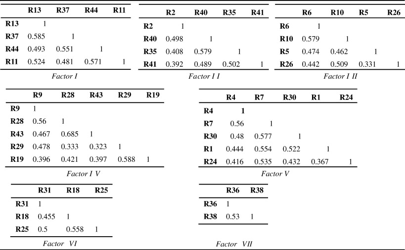

Table 6. Reliability Cronbach's alpha for the attributes.

| Attributes | Cronbach's alpha (C<sub>α</sub>) |
| --- | --- |
| Attributes in factor I | 0.816 |
| Attributes in factor II | 0.761 |
| Attributes in factor III | 0.773 |
| Attributes in factor IV | 0.811 |
| Attributes in factor V | 0.825 |
| Attributes in factor VI | 0.749 |
| Attributes in factor VII | 0.71 |
| All attributes selected for factor analysis | 0.91 |

### 3.7. Regression analysis

As already stated, the reasons of delay evolving from factor analysis are further analysed by linear multiple regression for potentially developing a predictive model in Indian construction context. While factor analysis depicts the existence of clusters of large correlation coefficients with measurable underlying dimensions, such dimensions (or factors) do not possess predictive power of any order on the measured phenomena. The factors are extracted based on parsimonious explanation of the maximum amount of common variance in a [correlation matrix](https://www.sciencedirect.com/topics/engineering/correlation-matrix) using the smallest number of exploratory concepts and the extracted factors are perceived to be of equal importance. However, multiple regression analysis fits a predictive model combining a set of independent variables in the entire dataset and without considering the common variance (value of R<sup>2</sup>) in the correlation matrix (Field, 2005). Value of R<sup>2</sup> provides a good gauge of substantive size of relationship between the predicting or dependent variable and the independent variables.

Before performing the regression analysis, some of the key underlying assumptions should be met in the [predictor variables](https://www.sciencedirect.com/topics/engineering/predictor-variable). In this research, the parametric test was conducted by analysing the homogeneity of variance (Levene's test) on the selected attributes before performing the regression analysis (Field, 2005). The results of Levene's test being significant (p < 0.05) suggest the rejection of the null hypothesis that variances between variables are zero and thus the regression analysis is tenable. The independent variables used are the attributes resulted from the factor analysis as shown in Table 4. Dependent variable is the impact of overall delay on project which has been asked separately to every respondent focusing on a selected project. These attributes are entered into regression model stepwise as categorical variables. Thus the regression model framed to measure the overall impact of delay caused by individual attributes can be expressed generally as$Y=a+b1X1+b2X2+…. bmXm±e$where Y is dependent variable, a is constant and intercepts at Y axis; b<sub>1</sub> to b<sub>m</sub> are estimated [regression coefficients](https://www.sciencedirect.com/topics/engineering/regression-coefficient); X<sub>1</sub> to X<sub>m</sub> are values of predictor or independent variables, e is error.

Forward stepwise process is used to formulate the regression model. Since it may not be the best fitting model, predictor variables with significant correlation with dependent variable is identified using Spearman correlation and models are again formulated with forward pass backward stepwise and forced entry. Out of formed models, the optimum model is selected based on strength of correlation (R<sup>2</sup>) which is a direct measure of % variance explained (Field, 2005). As the value of R<sup>2</sup> changes rapidly with the addition of new independent variables in the model, a good measure of strength in the model is *adjusted* R<sup>2</sup> values. The adjusted R<sup>2</sup> values and the change from R<sup>2</sup> values give the idea of how well the model generalises the predictive strength of the dependent variable (Doloi, 2009). In an ideal case, values of R<sup>2</sup> and adjusted R<sup>2</sup> should be the same. The difference between R<sup>2</sup> and adjusted R<sup>2</sup> gives the predictive strength of the model, the lesser the difference is, the stronger the model (Field, 2005).Based on the goodness of the model fit, the values shown in Table 7 are acceptable with reasonable strengths.

Table 7. Regression model.

| Source | Coefficient | Std error | Prob. | R<sup>2</sup>/adj R<sup>2</sup> |
| --- | --- | --- | --- | --- |
| Intercept | − 0.853 | 0.346 | 0.0163 | R<sup>2</sup> = 0.766/adj R<sup>2</sup> = 0.747 F = 41.219 p = 0.00001 Dublin–Watson = 2.224 |
| R10 | 0.368 | 0.082 | 0.0000 |  |
| R25 | 0.177 | 0.079 | 0.0283 |  |
| R40 | 0.165 | 0.076 | 0.0321 |  |
| R26 | 0.299 | 0.090 | 0.0014 |  |
| R7 | 0.325 | 0.067 | 0.0011 |  |

The final regression model for impact of delay can be expressed as:$Impact of Delay=−0.853+0.368(Slow decision from owner)+0.177Consultant or Architect's reluctance for change+0.165Poor labour productivity+0.299Poor site management and supervision+0.325Rework due to errors in execution.$

As seen clearly from the regression model, slow decisions from owner (R10) and rework due to errors in execution (R7) have maximum impact on delay duration in Indian construction projects. Slow decisions from owner and consultant's reluctance for change (R25) are usually the results of overly exercised bureaucracy in project development environment. Rework due to errors in execution is again the result of lack of appropriate quality planning and implementation of quality control processes onsite. Poor labour productivity (R40) is partly due to use of unskilled labour without appropriate match to the required trade practices. Poor site management and supervision (R26) experienced across most Indian projects is partly due to lack of commitments and ad-hoc approaches among the construction professionals. These findings seem to have the synergy across practices in developing countries which are somewhat comparable to the findings of Aibinu and Jagboro, 2002, Sambasivan and Soon, 2007.

## 4. Conclusion

Despite a clear understanding of these key factors among the research communities, a sincere attempt to address this chronic issue of time overrun is yet to materialise amongst practitioners in the Indian construction industry. Traditionally, the approach to managing construction is quite ad-hoc on Indian projects and need for adopting a systematic approach has not been realised across the board. This became evident on the world arena during the execution stage of programmes and projects during the recently concluded Commonwealth Games 2010. In the advent of the rapid urbanisation and fast growth in construction industry, these factors must be considered and well-integrated in the main stream [construction processes](https://www.sciencedirect.com/topics/engineering/construction-process) for improving industry practices across the construction projects. Benchmarking data on performance of Indian construction projects is not available. Recently efforts to measure, especially on large infrastructure projects, time and cost performance have begun. In 2009, the Bureau of Indian Standards released the first guideline on [construction project management](https://www.sciencedirect.com/topics/engineering/construction-project-management). The path forward requires setting of standards, benchmarking performance, skills development, and research undertakings in project management. Via this research the authors have attempted to highlight some of these issues. Consequently these findings are envisioned to be significant contributions to the Indian construction industry in controlling the time overruns on construction projects.

### 4.1. Limitations of the research

Though best efforts were put in this research and findings do make a significant contribution for industry, this research has some limitations. First the sample size of 77 is considered to be on the smaller side for statistical analysis. Secondly the respondents are not evenly distributed among the professional roles which may have induced some bias in responses. Thus the model formed may be further honed based on detailed discussions and suggestions from industry experts. The relationship between various reasons of delay and its impact on overall project delay has to be detailed further which is the author's intended future work.

## References

1. Ahsan and Gunawan, 2010

   M.K. Ahsan, I. Gunawan

   Analysis of cost and schedule performance of international development projects

   International Journal of Project Management, 28 (2010), pp. 68-78

   [View in Scopus](https://www.scopus.com/inward/record.url?eid=2-s2.0-70450263655&partnerID=10&rel=R3.0.0)[Google Scholar](https://scholar.google.com/scholar_lookup?title=Analysis%20of%20cost%20and%20schedule%20performance%20of%20international%20development%20projects&publication_year=2010&author=M.K.%20Ahsan&author=I.%20Gunawan)
2. Aibinu and Jagboro, 2002

   A.A. Aibinu, G.O. Jagboro

   The effects of construction delays on project delivery in Nigerian construction industry

   International Journal of Project Management, 20 (2002), pp. 593-599

   [View PDF](https://www.sciencedirect.com/science/article/pii/S0263786302000285/pdfft?md5=7ecd76777d948c1608ef5b78346c4a07&pid=1-s2.0-S0263786302000285-main.pdf)[View article](https://www.sciencedirect.com/science/article/pii/S0263786302000285)[View in Scopus](https://www.scopus.com/inward/record.url?eid=2-s2.0-0036836295&partnerID=10&rel=R3.0.0)Google Scholar
3. Aibinu and Odeyinka, 2006

   A.A. Aibinu, H.A. Odeyinka

   Construction delays and their causative factors in Nigeria

   Journal of Construction Engineering Management, 132 (2006), pp. 667-677

   [View in Scopus](https://www.scopus.com/inward/record.url?eid=2-s2.0-33745311973&partnerID=10&rel=R3.0.0)[Google Scholar](https://scholar.google.com/scholar_lookup?title=Construction%20delays%20and%20their%20causative%20factors%20in%20Nigeria&publication_year=2006&author=A.A.%20Aibinu&author=H.A.%20Odeyinka)
4. Al-Khalil and AL-Ghafly, 1999

   M. Al-Khalil, M. AL-Ghafly

   Important causes of delay in public utility projects in Saudi Arabia

   Journal of Construction Management and Economics, 17 (1999)

   [Google Scholar](https://scholar.google.com/scholar_lookup?title=Important%20causes%20of%20delay%20in%20public%20utility%20projects%20in%20Saudi%20Arabia&publication_year=1999&author=M.%20Al-Khalil&author=M.%20AL-Ghafly)
5. Al-Kharashi and Skitmore, 2009

   A. Al-Kharashi, M. Skitmore

   Causes of delays in Saudi Arabian public sector construction projects

   Construction Management and Economics, 27 (2009), pp. 3-23

   [CrossRef](https://doi.org/10.1080/01446190802541457)[View in Scopus](https://www.scopus.com/inward/record.url?eid=2-s2.0-61649124532&partnerID=10&rel=R3.0.0)[Google Scholar](https://scholar.google.com/scholar_lookup?title=Causes%20of%20delays%20in%20Saudi%20Arabian%20public%20sector%20construction%20projects&publication_year=2009&author=A.%20Al-Kharashi&author=M.%20Skitmore)
6. Arditi et al., 1985

   D. Arditi, G.T. Akan, S. Gurdamar

   Reasons for delays in public projects in Turkey

   Construction Management and Economics, 3 (1985), pp. 171-181

   [CrossRef](https://doi.org/10.1080/01446198500000013)[View in Scopus](https://www.scopus.com/inward/record.url?eid=2-s2.0-0006865274&partnerID=10&rel=R3.0.0)[Google Scholar](https://scholar.google.com/scholar_lookup?title=Reasons%20for%20delays%20in%20public%20projects%20in%20Turkey&publication_year=1985&author=D.%20Arditi&author=G.T.%20Akan&author=S.%20Gurdamar)
7. Assaf and Al-Hejji, 2006

   S.A. Assaf, S. Al-Hejji

   Causes of delay in large construction projects

   International Journal of Project Management, 24 (2006), pp. 349-357

   [View PDF](https://www.sciencedirect.com/science/article/pii/S0263786305001262/pdfft?md5=4f3e90c66f322ebaf9f08f483c3ab970&pid=1-s2.0-S0263786305001262-main.pdf)[View article](https://www.sciencedirect.com/science/article/pii/S0263786305001262)[View in Scopus](https://www.scopus.com/inward/record.url?eid=2-s2.0-33645965860&partnerID=10&rel=R3.0.0)[Google Scholar](https://scholar.google.com/scholar_lookup?title=Causes%20of%20delay%20in%20large%20construction%20projects&publication_year=2006&author=S.A.%20Assaf&author=S.%20Al-Hejji)
8. Assaf et al., 1995

   S.A. Assaf, M. Al-Khalil, M. Al-Hazmi

   Causes of delays in large building construction projects

   ASCE Journal of Management in Engineering, 11 (1995), pp. 45-50

   [View in Scopus](https://www.scopus.com/inward/record.url?eid=2-s2.0-84927635730&partnerID=10&rel=R3.0.0)[Google Scholar](https://scholar.google.com/scholar_lookup?title=Causes%20of%20delays%20in%20large%20building%20construction%20projects&publication_year=1995&author=S.A.%20Assaf&author=M.%20Al-Khalil&author=M.%20Al-Hazmi)
9. Bramble and Callahan, 1992

   B.B. Bramble, M.T. Callahan

   Construction Delay Claims

   Wiley Law Publications, New York (1992)

   [Google Scholar](https://scholar.google.com/scholar_lookup?title=Construction%20Delay%20Claims&publication_year=1992&author=B.B.%20Bramble&author=M.T.%20Callahan)
10. Chan and Kumaraswamy, 1997

    D.W. Chan, M.M. Kumaraswamy

    A comparative study of causes of time overruns in Hong Kong construction projects

    International Journal of Project Management, 15 (1997), pp. 55-63

    [View PDF](https://www.sciencedirect.com/science/article/pii/S0263786396000397/pdf?md5=bb26fd22fdee2511b83d5f954b6bef31&pid=1-s2.0-S0263786396000397-main.pdf)[View article](https://www.sciencedirect.com/science/article/pii/S0263786396000397)[View in Scopus](https://www.scopus.com/inward/record.url?eid=2-s2.0-0031078243&partnerID=10&rel=R3.0.0)Google Scholar
11. Doloi, 2008

    H. Doloi

    Analysing the novated design and construct contract from the client's, design team's and contractor's perspectives

    Construction Management and Economics, 26 (2008), pp. 1181-1196

    [CrossRef](https://doi.org/10.1080/01446190802512359)[View in Scopus](https://www.scopus.com/inward/record.url?eid=2-s2.0-57449104522&partnerID=10&rel=R3.0.0)Google Scholar
12. Doloi, 2009

    H. Doloi

    Analysis of pre-qualification criteria in contractor selection and their impacts on project success

    Construction Management and Economics, 27 (2009), pp. 1245-1263

    [CrossRef](https://doi.org/10.1080/01446190903394541)[View in Scopus](https://www.scopus.com/inward/record.url?eid=2-s2.0-77449117316&partnerID=10&rel=R3.0.0)Google Scholar
13. El-Razek et al., 2008

    A.M.E. El-Razek, H.A. Bassioni, A.M. Mobarak

    Causes of delay in building construction projects in Egypt

    Journal of Construction Engineering Management, 134 (2008), pp. 831-841

    Google Scholar
14. Faridi and El-Sayegh, 2006

    A. Faridi, S. El-Sayegh

    Significant factors causing delay in the UAE construction industry

    Construction Management and Economics, 24 (2006), pp. 1167-1176

    [CrossRef](https://doi.org/10.1080/01446190600827033)[View in Scopus](https://www.scopus.com/inward/record.url?eid=2-s2.0-33751295266&partnerID=10&rel=R3.0.0)[Google Scholar](https://scholar.google.com/scholar_lookup?title=Significant%20factors%20causing%20delay%20in%20the%20UAE%20construction%20industry&publication_year=2006&author=A.%20Faridi&author=S.%20El-Sayegh)
15. Field, 2005

    A. Field

    Discovering Statistics Using SPSS

    Sage, London (2005)

    [Google Scholar](https://scholar.google.com/scholar_lookup?title=Discovering%20Statistics%20Using%20SPSS&publication_year=2005&author=A.%20Field)
16. Iyer and Jha, 2005

    K.C. Iyer, K.N. Jha

    Factors affecting cost performance: evidence from Indian construction projects

    International Journal of Project Management, 23 (2005), pp. 283-295

    [View PDF](https://www.sciencedirect.com/science/article/pii/S0263786304001000/pdfft?md5=3a8de8fc9aeee2814f34cc62b5021cec&pid=1-s2.0-S0263786304001000-main.pdf)[View article](https://www.sciencedirect.com/science/article/pii/S0263786304001000)[View in Scopus](https://www.scopus.com/inward/record.url?eid=2-s2.0-18144374111&partnerID=10&rel=R3.0.0)[Google Scholar](https://scholar.google.com/scholar_lookup?title=Factors%20affecting%20cost%20performance%3A%20evidence%20from%20Indian%20construction%20projects&publication_year=2005&author=K.C.%20Iyer&author=K.N.%20Jha)
17. Kadir et al., 2005

    M.R.A. Kadir, W.P. Lee, M.S. Jaafar, S.M. Sapuan, A.A.A. Ali

    Factors affecting construction labour productivity for Malaysian residential projects

    Structural Survey, 23 (2005), pp. 42-54

    Google Scholar
18. Kaiser, 1974

    H.F. Kaiser

    An index of factorial simplicity

    Psychometrika, 39 (1974), pp. 31-36

    [View in Scopus](https://www.scopus.com/inward/record.url?eid=2-s2.0-34250421484&partnerID=10&rel=R3.0.0)[Google Scholar](https://scholar.google.com/scholar_lookup?title=An%20index%20of%20factorial%20simplicity&publication_year=1974&author=H.F.%20Kaiser)
19. Kim et al., 2008

    H. Kim, L. Soibelman, F. Groblera

    Factor selection for delay analysis using knowledge discovery in databases

    Automation in Construction, 17 (2008), pp. 550-560

    [View PDF](https://www.sciencedirect.com/science/article/pii/S0926580507001306/pdfft?md5=a35555f6e5c7473e0d128da24651ab4e&pid=1-s2.0-S0926580507001306-main.pdf)[View article](https://www.sciencedirect.com/science/article/pii/S0926580507001306)[View in Scopus](https://www.scopus.com/inward/record.url?eid=2-s2.0-40649108560&partnerID=10&rel=R3.0.0)Google Scholar
20. Kumaraswamy and Chan, 1998

    M.M. Kumaraswamy, D.W.M. Chan

    Contributors to construction delays

    Construction Management and Economics, 16 (1998), pp. 17-29

    [View in Scopus](https://www.scopus.com/inward/record.url?eid=2-s2.0-0001798497&partnerID=10&rel=R3.0.0)[Google Scholar](https://scholar.google.com/scholar_lookup?title=Contributors%20to%20construction%20delays&publication_year=1998&author=M.M.%20Kumaraswamy&author=D.W.M.%20Chan)
21. Ling and Hoi, 2006

    F.Y.Y. Ling, L. Hoi

    Risks faced by Singapore firms when undertaking construction projects in India

    International Journal of Project Management, 24 (2006), pp. 261-270

    [View PDF](https://www.sciencedirect.com/science/article/pii/S0263786305001195/pdfft?md5=978b1a43dfd291df6d8ff25e3ca64a1c&pid=1-s2.0-S0263786305001195-main.pdf)[View article](https://www.sciencedirect.com/science/article/pii/S0263786305001195)[View in Scopus](https://www.scopus.com/inward/record.url?eid=2-s2.0-33645542004&partnerID=10&rel=R3.0.0)[Google Scholar](https://scholar.google.com/scholar_lookup?title=Risks%20faced%20by%20Singapore%20firms%20when%20undertaking%20construction%20projects%20in%20India&publication_year=2006&author=F.Y.Y.%20Ling&author=L.%20Hoi)
22. Lo et al., 2006

    T.Y. Lo, I.W.H. Fung, K.C.F. Tung

    Construction delays in Hong Kong civil engineering projects

    Journal of Construction Engineering Management, 132 (2006), pp. 636-649

    [View in Scopus](https://www.scopus.com/inward/record.url?eid=2-s2.0-33646751898&partnerID=10&rel=R3.0.0)[Google Scholar](https://scholar.google.com/scholar_lookup?title=Construction%20delays%20in%20Hong%20Kong%20civil%20engineering%20projects&publication_year=2006&author=T.Y.%20Lo&author=I.W.H.%20Fung&author=K.C.F.%20Tung)
23. Mansfield et al., 1994

    N. Mansfield, O. Ugwu, T. Doran

    Causes of delay and cost overruns in Nigerian construction projects

    International Journal of Project Management, 12 (1994), pp. 254-260

    [View PDF](https://www.sciencedirect.com/science/article/pii/0263786394900507/pdf?md5=1ce52cb7572dc7e72841819a07ff9fd7&pid=1-s2.0-0263786394900507-main.pdf)[View article](https://www.sciencedirect.com/science/article/pii/0263786394900507)[View in Scopus](https://www.scopus.com/inward/record.url?eid=2-s2.0-0000725583&partnerID=10&rel=R3.0.0)Google Scholar
24. Nkadoa, 1995

    R.N. Nkadoa

    Construction time-influencing factors: the contractor's perspective

    Construction Management and Economics, 13 (1995), pp. 81-89

    [Google Scholar](https://scholar.google.com/scholar_lookup?title=Construction%20time-influencing%20factors%3A%20the%20contractors%20perspective&publication_year=1995&author=R.N.%20Nkadoa)
25. Odeh and Battaine, 2002

    A.M. Odeh, H.T. Battaine

    Causes of construction delay: traditional contracts

    International Journal of Project Management, 20 (2002), pp. 67-73

    [View PDF](https://www.sciencedirect.com/science/article/pii/S0263786300000375/pdfft?md5=5cec5928869b0714931ba7670cb405e7&pid=1-s2.0-S0263786300000375-main.pdf)[View article](https://www.sciencedirect.com/science/article/pii/S0263786300000375)[View in Scopus](https://www.scopus.com/inward/record.url?eid=2-s2.0-0036132474&partnerID=10&rel=R3.0.0)[Google Scholar](https://scholar.google.com/scholar_lookup?title=Causes%20of%20construction%20delay%3A%20traditional%20contracts&publication_year=2002&author=A.M.%20Odeh&author=H.T.%20Battaine)
26. Odeyinka and Yusif, 1997

    H.A. Odeyinka, A. Yusif

    The causes and effects of construction delays on completion cost of housing projects in Nigeria

    Journal of Financial Management of Property and Construction, 2 (1997), pp. 31-44

    Google Scholar
27. Olawale and Sun, 2010

    Y.A. Olawale, M. Sun

    Cost and time control of construction projects: inhibiting factors and mitigating measures in practice

    Construction Management and Economics, 28 (2010), pp. 509-526

    [CrossRef](https://doi.org/10.1080/01446191003674519)[View in Scopus](https://www.scopus.com/inward/record.url?eid=2-s2.0-77953674695&partnerID=10&rel=R3.0.0)Google Scholar
28. Sambasivan and Soon, 2007

    M. Sambasivan, Y.W. Soon

    Causes and effects of delays in Malaysian construction industry

    International Journal of Project Management, 25 (2007), pp. 517-526

    [View PDF](https://www.sciencedirect.com/science/article/pii/S0263786306001700/pdfft?md5=0c135a8f3225df9a6d6f46a704d01b49&pid=1-s2.0-S0263786306001700-main.pdf)[View article](https://www.sciencedirect.com/science/article/pii/S0263786306001700)[View in Scopus](https://www.scopus.com/inward/record.url?eid=2-s2.0-34248402903&partnerID=10&rel=R3.0.0)[Google Scholar](https://scholar.google.com/scholar_lookup?title=Causes%20and%20effects%20of%20delays%20in%20Malaysian%20construction%20industry&publication_year=2007&author=M.%20Sambasivan&author=Y.W.%20Soon)
29. Satyanarayana and Iyer, 1996

    K.N. Satyanarayana, K.C. Iyer

    Evaluation of delays in Indian construction contracts

    Journal of the Institution of Engineers (India), 77 (1996), pp. 14-22

    [Google Scholar](https://scholar.google.com/scholar_lookup?title=Evaluation%20of%20delays%20in%20Indian%20construction%20contracts&publication_year=1996&author=K.N.%20Satyanarayana&author=K.C.%20Iyer)
30. Semple et al., 1994

    C. Semple, F. Hartman, G. Jergeas

    Construction claims and disputes: causes and cost/time overruns

    ASCE Journal of Construction, Engineering and Management, 120 (4) (1994), pp. 785-795

    [View in Scopus](https://www.scopus.com/inward/record.url?eid=2-s2.0-0028754078&partnerID=10&rel=R3.0.0)[Google Scholar](https://scholar.google.com/scholar_lookup?title=Construction%20claims%20and%20disputes%3A%20causes%20and%20costtime%20overruns&publication_year=1994&author=C.%20Semple&author=F.%20Hartman&author=G.%20Jergeas)
31. Vaus, 2001

    Vaus, D.A., 2001. Research Design in Social Science, Sage Publications Ltd. London.

    [Google Scholar](https://scholar.google.com/scholar?q=Vaus%2C%20D.A.%2C%202001.%20Research%20Design%20in%20Social%20Science%2C%20Sage%20Publications%20Ltd.%20London.)
32. Zhang, 2005

    X. Zhang

    Concessionaire's financial capability in developing build–operate–transfer type infrastructure projects

    Journal of Construction Engineering and Management, 131 (2005), pp. 1054-1064

    [View in Scopus](https://www.scopus.com/inward/record.url?eid=2-s2.0-26644443645&partnerID=10&rel=R3.0.0)[Google Scholar](https://scholar.google.com/scholar_lookup?title=Concessionaires%20financial%20capability%20in%20developing%20buildoperatetransfer%20type%20infrastructure%20projects&publication_year=2005&author=X.%20Zhang)

### [A case-based reasoning approach for solving schedule delay problems in prefabricated construction projects](https://www.sciencedirect.com/science/article/pii/S0926580523002881)

- 2023, Automation in Construction

### [A comprehensive mathematical model for quality integration in a project supply chain with concentrating on material flow and transportation](https://www.sciencedirect.com/science/article/pii/S1474034623001623)

- 2023, Advanced Engineering Informatics

### [Evaluating the effectiveness of strategies for implementation of health and safety programs on construction sites in Nigeria: A mixed-method study](https://www.sciencedirect.com/science/article/pii/S0022437523000166)

- 2023, Journal of Safety Research

### [Technology readiness of B2B firms and AI-based customer relationship management capability for enhancing social sustainability performance](https://www.sciencedirect.com/science/article/pii/S0148296322009900)

- 2023, Journal of Business Research

### [Commercial office portfolio risks during the COVID pandemic and the future beyond – a survey of stakeholders in India](https://doi.org/10.1108/JPIF-03-2023-0019)

- 2023, Journal of Property Investment and Finance

### [Examining the Effect of Material Management Practices on Material Availability and Waste Reduction in Construction Projects](https://doi.org/10.1061/JCEMD4.COENG-13589)

- 2023, Journal of Construction Engineering and Management

[View all citing articles on Scopus](http://www.scopus.com/scopus/inward/citedby.url?partnerID=10&rel=3.0.0&eid=2-s2.0-84859216741&md5=594234137f3ed6d1a8b42b1704a3cb3)

[View Abstract](https://www.sciencedirect.com/science/article/abs/pii/S0263786311001384)

Copyright © 2011 APM and IPMA and Elsevier Ltd. Published by Elsevier Ltd. All rights reserved.

  Ghazi Saad A. Elawi, …, Dean Kashiwagi

  [View PDF](https://www.sciencedirect.com/science/article/pii/S1877705816301837/pdf?md5=1db2d4b7d42cf6efa057bbe867fe3243&pid=1-s2.0-S1877705816301837-main.pdf)

### [Factors influencing safety performance on construction projects: A review](https://www.sciencedirect.com/science/article/pii/S0925753516304234)

- Safety Science, Volume 109, 2018, pp. 382-397

  Amir Mohammadi, …, Yahya Khosravi

  [View PDF](https://www.sciencedirect.com/science/article/pii/S0925753516304234/pdfft?md5=691660d7ae23c08941a7bb6f5bbad72e&pid=1-s2.0-S0925753516304234-main.pdf)

### [Measuring Delays—The Basics](https://www.sciencedirect.com/science/article/pii/B9780128112441000057)

- Construction Delays, 2018, pp. 83-108

  Mark F. Nagata, …, Theodore J. Trauner

  [View PDF](https://www.sciencedirect.com/science/article/pii/B9780128112441000057/pdfft?md5=dbaeb8bdaf6d8870ace7a40513bf57b9&pid=3-s2.0-B9780128112441000057-main.pdf)

Citations

Captures

Social Media

- Shares, Likes & Comments: 11

[View details](https://plu.mx/plum/a/?doi=10.1016/j.ijproman.2011.10.004&theme=plum-sciencedirect-theme&hideUsage=true)